# Listening to sad music during induced sadness

# Manipulation check

```r
apa::t_apa(t.test(data$PostInduction, data$Baseline,
                  paired = TRUE))
```

```
## t(381) = 14.01, p < .001, d = 0.72
```

The manipulation of sadness was successful

# Pre to Post listening increase

```r
apa::t_apa(t.test(data$PostListening, data$PostInduction,
                  paired = TRUE))
```

```
## t(381) = 6.36, p < .001, d = 0.33
```

Sadness also increased from pre to post Listening

# Effect of Rumination

First I need to make long data

```r
data_long <- data %>%
  pivot_longer(cols = c("PostInduction", "PostListening"),
               names_to = "Timepoint",
               values_to = "Sadness")
```

Here I fit a series of general linear mixed models and compare them

```r
# Model 1 is the hypiothesised model

mod1 <- lmerTest::lmer(Sadness~Timepoint*rumination + (1|ID),
                       data = data_long,
                       REML = FALSE)

# Model 2 I control for th interaction with baseline sadness
mod2 <- lmerTest::lmer(Sadness~
                         Timepoint * rumination +
                         Timepoint * Baseline +
                         (1|ID),
                       data = data_long,
                       REML = FALSE)
# Model 3 I add the theoretically relvant BRECVEMA mechanisms of Contagion

mod3 <- lmerTest::lmer(Sadness~
                         Timepoint * rumination +
                         Timepoint * Baseline +
                         Timepoint* Contagion +
                         (1|ID),
                       data = data_long,
                       REML = FALSE)

# Model 4 I add the marginally significant mechanisms predicted by rumination
mod4 <- lmerTest::lmer(Sadness~
                         Timepoint * rumination +
                         Timepoint * Baseline +
                         Timepoint* Contagion +
                         Timepoint * Conditioning +
                         Timepoint * Memory +
                         (1|ID),
                       data = data_long,
                       REML = FALSE)

# Model 5 I add appraisal

mod5 <- lmerTest::lmer(Sadness~
                         Timepoint * rumination +
                         Timepoint * Baseline +
                         Timepoint* Contagion +
                         Timepoint* Appraisal +
                         Timepoint * Conditioning +
                         Timepoint * Memory +
                         (1|ID),
                       data = data_long,
                       REML = FALSE)

mod6 <- lmerTest::lmer(Sadness~
                         Timepoint * rumination +
                         Timepoint * Baseline +
                         Timepoint* Contagion +
                         Timepoint* Appraisal +
                         Timepoint * Conditioning +
                         Timepoint * Memory +
                         Timepoint * rumination * Appraisal +
                         (1|ID),
                       data = data_long,
                       REML = FALSE)

AIC(mod1, mod2, mod3, mod4, mod5, mod6)
```

```
##      df      AIC
## mod1  6 4424.764
## mod2  8 4189.239
## mod3 10 4179.327
## mod4 14 4153.408
## mod5 16 4143.783
## mod6 18 4147.532
```

From the AIC it can be seen the `mod5` is the best fit

```r
sjPlot::tab_model(mod1, mod5,
                  show.est = FALSE,
                  show.std = TRUE,
                  show.aic = TRUE)
```

|  | Sadness |  |  | Sadness |  |  |
| --- | --- | --- | --- | --- | --- | --- |
| Predictors | std. Beta | standardized CI | p | std. Beta | standardized CI | p |
| (Intercept) |  |  | **0.001** |  |  | **0.008** |
| Post Listening | -0.09 | -0.28 – 0.10 | 0.352 | -0.29 | -0.50 – -0.08 | **0.007** |
| rumination | 0.23 | 0.14 – 0.33 | **<0.001** | 0.07 | -0.01 – 0.14 | 0.079 |
| TimepointPostListening:rumination | 0.20 | 0.01 – 0.39 | **0.036** | 0.18 | -0.01 – 0.37 | 0.070 |
| Baseline |  |  |  | 0.65 | 0.57 – 0.73 | **<0.001** |
| Yes |  |  |  | -0.03 | -0.10 – 0.05 | 0.486 |
| Yes |  |  |  | 0.13 | 0.06 – 0.21 | **<0.001** |
| Yes |  |  |  | -0.03 | -0.10 – 0.05 | 0.488 |
| Yes |  |  |  | 0.00 | -0.07 – 0.08 | 0.917 |
| TimepointPostListening:Baseline |  |  |  | -0.08 | -0.16 – -0.00 | **0.043** |
| TimepointPostListening:ContagionYes |  |  |  | 0.09 | 0.02 – 0.16 | **0.017** |
| TimepointPostListening:AppraisalYes |  |  |  | -0.06 | -0.11 – -0.01 | **0.015** |
| TimepointPostListening:ConditioningYes |  |  |  | 0.14 | 0.07 – 0.20 | **<0.001** |
| TimepointPostListening:MemoryYes |  |  |  | 0.15 | 0.04 – 0.27 | **0.011** |
| Random Effects |  |  |  |  |  |  |
| σ<sup>2</sup> | 6.97 |  |  | 6.40 |  |  |
| τ<sub>00</sub> | 22.09 <sub>ID</sub> |  |  | 10.20 <sub>ID</sub> |  |  |
| ICC | 0.76 |  |  | 0.61 |  |  |
| N | 382 <sub>ID</sub> |  |  | 380 <sub>ID</sub> |  |  |
| Observations | 764 |  |  | 760 |  |  |
| Marginal R<sup>2</sup> / Conditional R<sup>2</sup> | 0.086 / 0.781 |  |  | 0.477 / 0.798 |  |  |
| AIC | 4424.764 |  |  | 4143.783 |  |  |

I will now set up reference grids for eah of the models

```r
mean_rum <- mean(data$rumination, na.rm = TRUE)
plus_rum <- mean_rum + sd(data$rumination, na.rm = TRUE)
minus_rum <- mean_rum - sd(data$rumination, na.rm = TRUE)

mean_baseline <- mean(data$Baseline, na.rm = TRUE)
plus_baseline <- mean_rum + sd(data$Baseline, na.rm = TRUE)
minus_baseline <- mean_rum - sd(data$Baseline, na.rm = TRUE)

hyp_grid <- emmeans::ref_grid(mod1,
                              at = list(rumination = c(minus_rum, mean_rum, plus_rum),
                                        Timepoint = c("PostInduction", "PostListening")))
```

# Hypothesised Model Plot

## Rumination

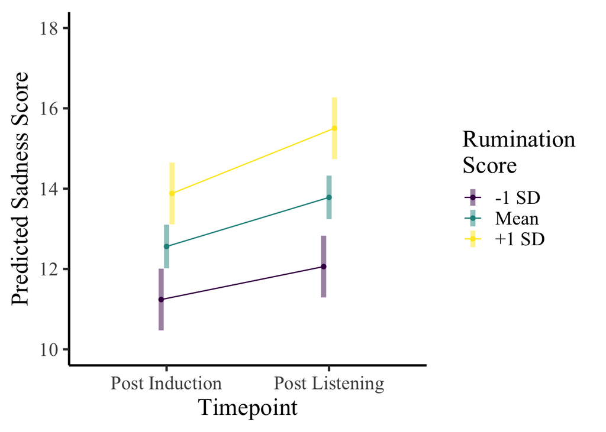

```r
rum_simple_plot <- emmeans::emmip(hyp_grid,
                                  formula = rumination ~ Timepoint,
                                  CIs = TRUE,
                                  frequentist = TRUE) +
  ggplot2::scale_x_discrete(labels = c("Post Induction", "Post Listening")) +
  ggplot2::scale_colour_viridis_d(labels = c("-1 SD", "Mean", "+1 SD"),
                                name = "Rumination \nScore")+
  ggplot2::ylab("Predicted Sadness Score") +
  ggplot2::xlab("Timepoint") +
  ggplot2::ylim(c(10, 18)) +
  ggplot2::theme_classic(base_size = 20, base_family = "Times New Roman")


rum_simple_plot
```

## Johnson Neyman

As there are two levels to the timepoint factor we can look at the Johnson Neyman interval for rumination to indicate at what point of rumination an increase significantly predicted.

```r
jn_data <- data_long %>%
  mutate(Timepoint = if_else(Timepoint == "PostInduction", 0, 1))

jn_model <- lmer(Sadness~Timepoint + Timepoint * rumination + (1|ID),
                 data = jn_data,
                 REML = FALSE)

jn_rum <- interactions::johnson_neyman(model = jn_model,
                       pred = "Timepoint",
                       modx = "rumination"
                       )

print(jn_rum$bounds)
```

```
##      Lower     Higher
## -28.757182   2.868204
```

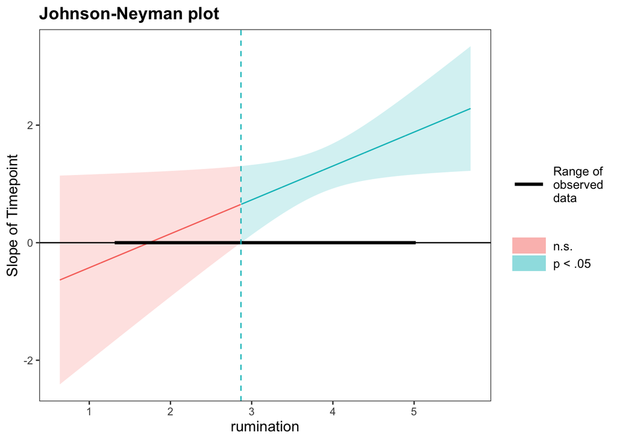

```r
jn_rum$plot
```

# Best fiting model

```r
mod5_grid <- emmeans::ref_grid(mod5,
                                   at = list(rumination = c(minus_rum, mean_rum, plus_rum),
                                             Baseline = c(minus_baseline, mean_baseline, plus_baseline),
                                             Contagion = c("No", "Yes"),
                                             Conditioning = c("No", "Yes"),
                                             Appraisal = c("No", "Yes"),
                                             Memory = c("No", "Yes")))
```

## Plots

Now I want to plot each of the interactions.

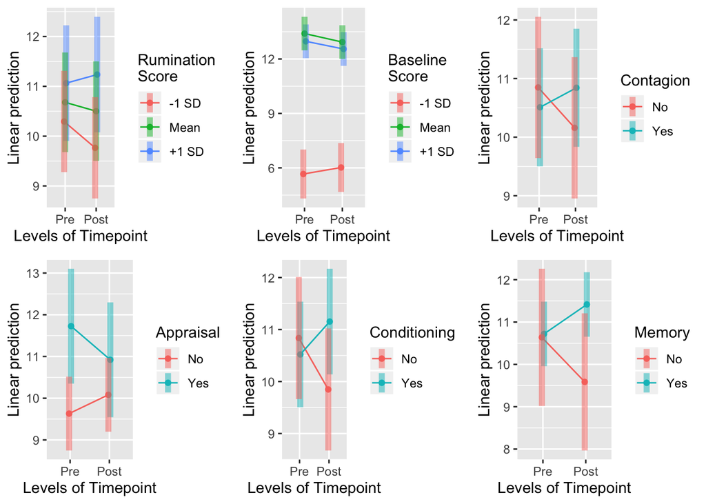

```r
rum_plot <- emmeans::emmip(mod5_grid,
               rumination~Timepoint,
               CIs = TRUE ) +
  ggplot2::scale_color_discrete(labels = c("-1 SD", "Mean", "+1 SD"),
                                name = "Rumination \nScore") +
  ggplot2::scale_x_discrete(labels = c("Pre", "Post"))


baseline_plot <- emmeans::emmip(mod5_grid,
               Baseline~Timepoint,
               CIs = TRUE ) +
  ggplot2::scale_color_discrete(labels = c("-1 SD", "Mean", "+1 SD"),
                                name = "Baseline \nScore") +
  ggplot2::scale_x_discrete(labels = c("Pre", "Post"))

contagion_plot <- emmeans::emmip(mod5_grid,
               Contagion~Timepoint,
               CIs = TRUE) +
  ggplot2::scale_x_discrete(labels = c("Pre", "Post"))

conditioing_plot <- emmeans::emmip(mod5_grid,
               Conditioning ~ Timepoint,
               CIs = TRUE) +
  ggplot2::scale_x_discrete(labels = c("Pre", "Post"))

appraisal_plot <- emmeans::emmip(mod5_grid,
               Appraisal~ Timepoint,
               CIs = TRUE) +
  ggplot2::scale_x_discrete(labels = c("Pre", "Post"))

memory_plot <- emmeans::emmip(mod5_grid,
               Memory ~ Timepoint,
               CIs = TRUE) +
  ggplot2::scale_x_discrete(labels = c("Pre", "Post"))

cowplot::plot_grid(rum_plot,
                   baseline_plot,
                   contagion_plot,
                   appraisal_plot,
                   conditioing_plot,
                   memory_plot)
```

We can see dense patterning here so I am going to create a scenario where BRECVEMA models are set in the most or least favourable way. In both cases appraisal has been set to No

[figure not shown]

```r
mod5_best <- emmeans::ref_grid(mod5,
                                   at = list(rumination = c(minus_rum, mean_rum, plus_rum),
                                            # Baseline = c(plus_baseline),
                                             Contagion = c("No"),
                                             Conditioning = c("No"),
                                            Appraisal = c("No"),
                                             Memory = c("No")))

mod5_worst <- emmeans::ref_grid(mod5,
                                   at = list(rumination = c(minus_rum, mean_rum, plus_rum),
                                            # Baseline = c(minus_baseline),
                                             Contagion = c("Yes"),
                                             Conditioning = c("Yes"),
                                            Appraisal = c("No"),
                                             Memory = c("Yes")))

mod5_contagion <- emmeans::ref_grid(mod5,
                                   at = list(rumination = c(minus_rum, mean_rum, plus_rum),
                                            # Baseline = c(plus_baseline),
                                             Contagion = c("Yes"),
                                             Conditioning = c("No"),
                                            Appraisal = c("No"),
                                             Memory = c("No")))

mod5_memory <- mod5_best <- emmeans::ref_grid(mod5,
                                   at = list(rumination = c(minus_rum, mean_rum, plus_rum),
                                            # Baseline = c(plus_baseline),
                                             Contagion = c("No"),
                                             Conditioning = c("No"),
                                            Appraisal = c("No"),
                                             Memory = c("Yes")))

plot_best <- emmeans::emmip(mod5_best,
               rumination ~ Timepoint,
               CIs = TRUE) +
  ggplot2::scale_x_discrete(labels = c("Pre", "Post")) +
  ggplot2::scale_color_discrete(labels = c("-1 SD", "Mean", "+1 SD"),
                                name = "Rumination \nScore") +
  ggplot2::ggtitle(label = "No inductive mechanisms") +
  ggplot2::ylim(c(8, 16))

plot_worst <- emmeans::emmip(mod5_worst,
               rumination ~ Timepoint,
               CIs = TRUE) +
  ggplot2::scale_x_discrete(labels = c("Pre", "Post")) +
  ggplot2::scale_color_discrete(labels = c("-1 SD", "Mean", "+1 SD"),
                                name = "Rumination \nScore") +
    ggplot2::ggtitle(label = "All inductive mechanisms") +
  ggplot2::ylim(c(8, 16))

plot_mem <- emmeans::emmip(mod5_memory, rumination ~ Timepoint,
               CIs = TRUE) +
  ggplot2::scale_x_discrete(labels = c("Pre", "Post")) +
  ggplot2::scale_color_discrete(labels = c("-1 SD", "Mean", "+1 SD"),
                                name = "Rumination \nScore") +
    ggplot2::ggtitle(label = "Memories Only") +
  ggplot2::ylim(c(8, 16))

plot_con <- emmeans::emmip(mod5_memory, rumination ~ Timepoint,
               CIs = TRUE) +
  ggplot2::scale_x_discrete(labels = c("Pre", "Post")) +
  ggplot2::scale_color_discrete(labels = c("-1 SD", "Mean", "+1 SD"),
                                name = "Rumination \nScore") +
    ggplot2::ggtitle(label = "Contagion Only") +
  ggplot2::ylim(c(8, 16))

cowplot::plot_grid(plot_best,
                   plot_worst,
                   plot_mem,
                   plot_con)
```

## Get pairwise contrasts

Here I am getting the contrasts for the plotted scenarios

```r
best_contrast <- emmeans::contrast(mod5_best,
                  "pairwise") %>%
  broom::tidy() %>%
  filter(stringr::str_starts(level1, "PostInduction")) %>%
  tidyr::separate(col = level1,
                  into = c("Timepoint", "rumination", "baseline", "Contagion", "Appraisal", "Conditioning", "Memory"),
                  sep = ",",
                  remove = TRUE) %>%
  tidyr::separate(col = level2,
                  into = c("Timepoint2", "rumination2", "baseline2", "Contagion2", "Appraisal2", "Conditioning2", "Memory2"),
                  sep = ",",
                  remove = TRUE) %>%
  filter(Timepoint == "PostInduction" &
           Timepoint2 == "PostListening" &
           rumination == rumination2 &
           baseline == baseline2 &
           Contagion == Contagion2 &
           Appraisal == Appraisal2 &
           Conditioning == Conditioning2 &
           Memory == Memory2) %>%
  select(-contains("2")) %>%
  mutate(scenario = "Best",
         rumination = if_else(rumination < 3.2, "-1 SD",
                              if_else(rumination > 4, "+1 SD",
                              "Mean"))) %>%
  select(scenario, everything(), -Timepoint, -baseline)

worst_contrast <- emmeans::contrast(mod5_worst,
                  "pairwise") %>%
  broom::tidy() %>%
  filter(stringr::str_starts(level1, "PostInduction")) %>%
  tidyr::separate(col = level1,
                  into = c("Timepoint", "rumination", "baseline", "Contagion", "Appraisal", "Conditioning", "Memory"),
                  sep = ",",
                  remove = TRUE) %>%
  tidyr::separate(col = level2,
                  into = c("Timepoint2", "rumination2", "baseline2", "Contagion2", "Appraisal2", "Conditioning2", "Memory2"),
                  sep = ",",
                  remove = TRUE) %>%
  filter(Timepoint == "PostInduction" &
           Timepoint2 == "PostListening" &
           rumination == rumination2 &
           baseline == baseline2 &
           Contagion == Contagion2 &
           Appraisal == Appraisal2 &
           Conditioning == Conditioning2 &
           Memory == Memory2) %>%
  select(-contains("2")) %>%
  mutate(scenario = "Worst",
         rumination = if_else(rumination < 3.2, "-1 SD",
                              if_else(rumination > 4, "+1 SD",
                              "Mean"))) %>%
  select(scenario, everything(), -Timepoint, -baseline)

contagion_contrast <- emmeans::contrast(mod5_contagion,
                  "pairwise") %>%
  broom::tidy() %>%
  filter(stringr::str_starts(level1, "PostInduction")) %>%
  tidyr::separate(col = level1,
                  into = c("Timepoint", "rumination", "baseline", "Contagion", "Appraisal", "Conditioning", "Memory"),
                  sep = ",",
                  remove = TRUE) %>%
  tidyr::separate(col = level2,
                  into = c("Timepoint2", "rumination2", "baseline2", "Contagion2", "Appraisal2", "Conditioning2", "Memory2"),
                  sep = ",",
                  remove = TRUE) %>%
  filter(Timepoint == "PostInduction" &
           Timepoint2 == "PostListening" &
           rumination == rumination2 &
           baseline == baseline2 &
           Contagion == Contagion2 &
           Appraisal == Appraisal2 &
           Conditioning == Conditioning2 &
           Memory == Memory2) %>%
  select(-contains("2")) %>%
  mutate(scenario = "Contagion Only",
         rumination = if_else(rumination < 3.2, "-1 SD",
                              if_else(rumination > 4, "+1 SD",
                              "Mean"))) %>%
  select(scenario, everything(), -Timepoint, -baseline)

memory_contrast <- emmeans::contrast(mod5_memory,
                  "pairwise") %>%
  broom::tidy() %>%
  filter(stringr::str_starts(level1, "PostInduction")) %>%
  tidyr::separate(col = level1,
                  into = c("Timepoint", "rumination", "baseline", "Contagion", "Appraisal", "Conditioning", "Memory"),
                  sep = ",",
                  remove = TRUE) %>%
  tidyr::separate(col = level2,
                  into = c("Timepoint2", "rumination2", "baseline2", "Contagion2", "Appraisal2", "Conditioning2", "Memory2"),
                  sep = ",",
                  remove = TRUE) %>%
  filter(Timepoint == "PostInduction" &
           Timepoint2 == "PostListening" &
           rumination == rumination2 &
           baseline == baseline2 &
           Contagion == Contagion2 &
           Appraisal == Appraisal2 &
           Conditioning == Conditioning2 &
           Memory == Memory2) %>%
  select(-contains("2")) %>%
  mutate(scenario = "Memory Only",
         rumination = if_else(rumination < 3.2, "-1 SD",
                              if_else(rumination > 4, "+1 SD",
                              "Mean"))) %>%
  select(scenario, everything(), -Timepoint, -baseline)


bind_rows(best_contrast, worst_contrast, contagion_contrast, memory_contrast) %>%
  select(-df, -statistic) %>%
  mutate(p.value = round(p.value, 4),
         significant = if_else(p.value < .05, "Sig", "NonSig"))
```

```
## # A tibble: 12 x 10
##    scenario rumination Contagion Appraisal Conditioning Memory estimate
##    <chr>    <chr>      <chr>     <chr>     <chr>        <chr>     <dbl>
##  1 Best     -1 SD      No        No        No           Yes      0.641
##  2 Best     Mean       No        No        No           Yes      0.291
##  3 Best     +1 SD      No        No        No           Yes     -0.0589
##  4 Worst    -1 SD      Yes       No        Yes          Yes     -2.00
##  5 Worst    Mean       Yes       No        Yes          Yes     -2.35
##  6 Worst    +1 SD      Yes       No        Yes          Yes     -2.70
##  7 Contagi… -1 SD      Yes       No        No           No       1.37
##  8 Contagi… Mean       Yes       No        No           No       1.02
##  9 Contagi… +1 SD      Yes       No        No           No       0.666
## 10 Memory … -1 SD      No        No        No           Yes      0.641
## 11 Memory … Mean       No        No        No           Yes      0.291
## 12 Memory … +1 SD      No        No        No           Yes     -0.0589
## # … with 3 more variables: std.error <dbl>, p.value <dbl>,
## #   significant <chr>
```